# Health Education

# 化學治療藥品 常見副作用

## 什麼是化學治療

化學治療的藥物可以經由血液循環進入癌細胞，抑制癌細胞生長，由於癌細胞分裂快速，對於化療藥物特別敏感。

化學治療的目的有下列幾種：

- 治癒癌症
- 避免癌細胞擴散
- 減緩癌細胞的增殖
- 緩解腫瘤所引起的不適
- 改善病人的生活品質

對於生長在器官上的腫瘤，手術切除仍是目前最主要也是最有效的治療方式，化學治療有可能會是在手術前或後進行，可以單獨使用一種藥物或同時使用多種藥物，也可能搭配標靶治療，化療的進行與否與藥物的選擇是由醫師依據每位病人的病況來決定。

## 化學治療副作用為什麼會發生

除了分裂快速的癌細胞對於化療藥物特別敏感容易受攻擊以外，人體本身也有每天都會分裂的正常細胞，而這些細胞也容易受到化療藥物的攻擊，攻擊在不同的細胞會產生相對應的副作用，主要是以下三種細胞：

- 黏膜細胞：口腔炎、腹瀉
- 骨髓細胞：貧血、免疫力降低、虛弱、異常出血
- 皮膚細胞：指甲病變、掉髮、過敏、皮膚乾癢、紅疹

副作用的發生及嚴重程度會因為使用的藥物、劑量與個人體質而定，這些副作用在本院的治療期間都會進行監測，醫師會評估嚴重程度來決定是否暫停該次化療，因此治療期間有任何的不適感回診時請完整地告知醫師；化學治療療程結束後，大部分受傷的組織都會慢慢地復原。

## 化學治療期間的保養原則

- 吃：少量多餐、高蛋白、維持體重
- 喝：多喝水，果汁、牛奶、營養補充品亦可
- 睡：多休息、充足睡眠，營造好的睡眠環境
- 動：避免劇烈運動，緩和運動
- 鬆：最難也是最重要的，放鬆心情，改變心境

## 常見化學治療副作用

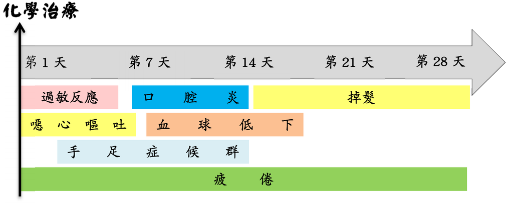

### 噁心、嘔吐

化學治療藥物注射後，最常也最快出現的副作用就是噁心、嘔吐，依症狀出現的時間可分為以下三種：

- 急性：在化學治療開始的24小時內即發生。
- 延遲性：在化學治療後超過24小時引發。
- 預期性：在前一次化學治療過程中，曾有過較嚴重的嘔吐，在此次給藥前或給藥時，就出現噁心嘔吐的情形。

因此通常在施打化學治療藥物前，會先給予止吐藥物加以預防，藉由正確使用預防性止吐藥，將可能發生的噁心嘔吐降到最低。 一般來說，噁心、嘔吐約在治療後的二至三天會得到緩解，有需要的話可以請醫師開止吐藥來減輕症狀，若情形加劇，則請告知醫師。

#### 化療期間飲食建議

- 少量多餐，多攝取高蛋白食物(像是奶、蛋、魚、肉類)。
- 避免油膩、油炸和過甜的食物，增加噁心或腸胃不適的機率。
- 胃口差、口腔破或是吞嚥困難時，可以將食物烹飪軟爛一點或是吃流質食物。
- 化療期間味覺可能會改變，可以佐以適當的香料(蔥、薑、香草等)調味來促進食慾。
- 若有脹氣的現象，避免食用含氣飲料或是豆製品(像是豆漿)。
- 有任何關於營養方面的問題，請洽詢營養師得到更多的資訊。

### 血球低下

化學治療藥物大多有骨髓抑制的副作用，導致骨髓造血功能無法正常運作，針對不同的血球抑制生長會出現不同的症狀：

- 白血球：發燒、畏寒、咳嗽、感染
- 紅血球：貧血、疲倦、頭暈
- 血小板：出血、莫名瘀青

#### 白血球減少：

在治療期間以白血球低下最常見，一般而言每一次治療結束後7-14天最常發生。白血球低下時抵抗力會下降，容易感染，特別是上呼吸道或泌尿道感染。

感染時最常出現的症狀為發燒、畏寒，若是在局部組織可能會有紅腫熱痛的現象，若有疑似感冒症狀或感染現象的發生，請盡快回診就醫。

化學治療期間醫師會監測白血球的變化，以評估該次是否適合進行療程，若白血球低於建議數值以下，則會暫停該次治療。

為了避免白血球下降時造成的風險，患者的自我保護很重要，建議保養方式如下：

- 勤洗手以維持手部清潔，注意手腕和指縫間的清洗
- 公共場合配戴口罩
- 若有傷口務必謹慎處理，消毒並且保護傷口
- 避免生食及未煮熟的食物
- 適時補充水分，不要憋尿
- 若有發生指甲病變的副作用，務必小心保護指尖
- 女性私密處的衛生要特別注意，避免尿道或陰道感染

#### 紅血球減少：

化療期間有可能因為抑制紅血球生長或血紅素生成的因素，造成貧血的現象，症狀可能會有虛弱、疲倦、怕冷、呼吸急促或頭暈等。若有以上症狀出現的話，回診時請告知醫師。

針對紅血球降低的建議保養方式如下：

- 避免劇烈運動，以緩和運動(散步、瑜珈、太極拳等)為主
- 運動時要注意避免太用力或是角度過大造成人工血管移位
- 適當的休息，充足的睡眠
- 小心因為姿勢性暈眩造成跌倒(像是下床起身或是蹲下後站立)，轉換姿勢時最好採取漸進式的方式
- 適量食用紅肉類或是深綠色蔬菜以補充鐵質吸收

#### 血小板減少：

血小板過低或是功能不佳會導致身體容易出血，輕微的症狀如瘀青、牙齦出血、流鼻血、月經不止、大小便帶血或傷口不易止血等，若有以上症狀回診時告知醫師即可。然而，嚴重的話會導致出血不止造成失血過多，因此若有發現出血不止的狀況請立即就醫。

針對血小板減少的注意事項如下：

- 若本身有在服用預防血栓的藥物(如阿斯匹靈、保栓通等抗凝血劑)，請主動告知醫師
- 避免劇烈運動或碰撞
- 使用軟毛牙刷，減少牙齦出血。
- 避免會造成高壓力的行為，如提重物、用力解便、用力擤鼻涕或用力挖鼻孔等造成血管破裂。
- 密切觀察有無莫名的出血徵象，如流鼻血、咳血、瘀青。

### 口腔炎、咽喉炎、食道炎

口腔、喉嚨和食道的黏膜細胞很容易受到化學治療藥物的影響，造成以下不適的症狀：味覺改變、口腔破皮、潰瘍、咽喉腫痛、食道發炎，有可能會因為以上的症狀導致吞嚥或進食困難，此時脆弱的口腔也容易受到細菌感染發炎，通常發生在化學治療開始的5至10天後，持續約7至14天才會逐漸癒合，因此化療期間口腔的衛生清潔相當重要。

針對口腔黏膜的保養方式建議如下：

- 避免食用太硬、尖銳、過熱或酸的食物，像是帶殼類的海鮮
- 使用軟毛牙刷，避免刺激牙齦
- 餐後漱口或以牙線做簡單的牙齒清潔，最好的話是刷牙
- 口乾時適時補充水分，隨身帶水保持口腔濕潤
- 塗抹護唇膏避免嘴唇乾裂
- 禁止抽菸、飲酒、檳榔
- 使用口內膏有助於口腔潰瘍癒合
- 吞嚥困難時可以食用較軟的食物，像是冰淇淋、布丁、蒸蛋或流質食物，甚至可以將食物燉爛一點或攪碎食用
- 口腔發熱腫痛時可以含冰塊以減少不適感

### 腹瀉、便祕

#### 腹瀉：

化學治療藥物容易造成腸道黏膜的刺激而導致腹瀉，嚴重的話會有發炎感染的現象。因此若有發現一天內有超過4~6次的腹瀉，甚至是伴有腹絞痛的症狀，應盡快回診就醫。

#### 便祕：

通常便祕較少發生，有些非消炎類的止痛藥可能會導致便秘的發生。另外，活動量不夠、長時間久坐或臥床、壓力過大或是水份補充不足亦有可能導致便秘。

針對腸胃道症狀的保養建議方式如下：

- 補充足夠的水分 (一般人建議每日2000-3000c.c.左右，若有心臟病要限水者則要詢問醫師的建議)
- 食用優格或含有益生菌的食品，維持腸道健康
- 若有便秘情況，請勿用力解便，清潔時肛門口時最好用衛生紙或濕紙巾輕拭就好，避免因為過度用力或乾燥造成肛門口破皮受傷
- 避免油炸、辛辣、過於油膩的食物，可能會刺激腸胃道導致腹瀉
- 含有咖啡因的飲食(像是茶、咖啡)，可能會增加腹瀉的情況
- 腹瀉情形頻繁時，應攝取清淡和低纖維的食物，少量多餐

### 皮膚反應、手足症候群

化療藥物可能會沿著注射的靜脈血管或是微血管滲透到周邊組織，造成皮膚細胞的刺激與色素沉澱，可能會發生以下症狀：

- 過敏反應：皮膚紅斑、紅疹、乾裂、刺癢
- 指甲病變：黑指甲、指甲脆弱易斷、指甲表面產生帶狀紋路
- 色素沉澱：膚色變深、沿著靜脈血管產生條狀的黑斑
- 手足症候群：手部或腳趾發紅、腫脹、發熱、龜裂

另外，毛囊細胞也因為生長快速的原因容易受到化療藥物刺激，導致掉髮的現象。

以上反應通常在化學治療後的第 2 至 12 天之間發生，療程結束後約 2 至 6 個月逐漸恢復。

針對皮膚在化療期間的建議保養方式如下：

- 塗抹乳液保持皮膚滋潤，特別是在手足的部分，最少早晚擦一次，尤其在洗澡後
- 洗澡時不宜用太熱的水，也不要泡澡泡太久
- 洗澡後擦乾身體時勿用力擦拭，以輕壓的方式將身體擦乾
- 加強防曬
- 穿著舒適寬鬆的衣服和鞋子，增加襪子厚度避免腳底的壓迫
- 手足症候群發作時可以用冰塊冰敷發作部位，改善腫脹的不適，建議冰敷時間約10~15分鐘，注意勿冰敷過久造成血液循環下降

### 周邊神經病變

化學治療藥物或有周邊神經毒性，可能會產生以下的不適症狀：手腳麻木、刺痛、感覺遲鈍、行動遲緩、平衡感失調、肌肉僵直、無力，也因此有可能在日常生活中的一些動作會有困難，像是扣鈕扣或是拿杯子，甚至是觸摸到冰冷或金屬的物體會有觸電感，這些症狀要在療程結束後的數月後可能逐漸恢復。

針對化療造成的神經病變保養方式建議如下：

- 建議使用杯子要有握把或是防滑墊，避免因為杯子滑落造成割傷危險
- 浴室建議要有止滑設備，避免因為動作不穩跌倒造成危險
- 天氣冷時要做好保暖措施，避免因為冷而加劇不適感
- 補充適量維他命，特別是 B 群會有助於神經的保養
- 適量的運動有助於緩解症狀，像是做一些甩手或搓手運動，促進末梢血液循環
- 症狀發作時可以熱敷以緩解不適感
- 若程度嚴重無法忍受時請向醫師反應

### 衛生防護應注意之事項

- 由於接受化療之病人的排泄物都會含有微量的化療藥物濃度，接受化療後的兩天內，建議照護者避免接觸到病人之排泄物，或是處理病人排泄物時應配戴口罩和手套，排泄物接觸過之表面，應以大量清水沖洗並且用漂白水進行擦拭。
- 漂白水一定要用次氯酸鈉的成分，至少要用3%的次氯酸鈉才能達到降解化療藥物活性的效果，一般市售為6%，購買回家後用清水對半稀釋即可。
- 擦拭過排泄物之廢棄物(如衛生紙、濕紙巾)，一定要用單獨的塑膠袋包好密封後再丟棄至一般垃圾桶。

# 癌症防治照護 常用超連結

## 台灣

- 台灣癌症基金會
- 癌症希望基金會，免費諮詢專線：0809-010-580
- 陶聲洋防癌基金會
- 台灣癌症資訊全人關懷協會
- 癌症防治基金會

## 香港

- 癌症基金會

## 中國大陸

- 中國癌症基金會

## 日本

- 日本癌治療学会
- 国立がん研究センター

## 美國

- 美國癌症協會